# AP Test Analysis

### AP Interims & AP Pass Rates

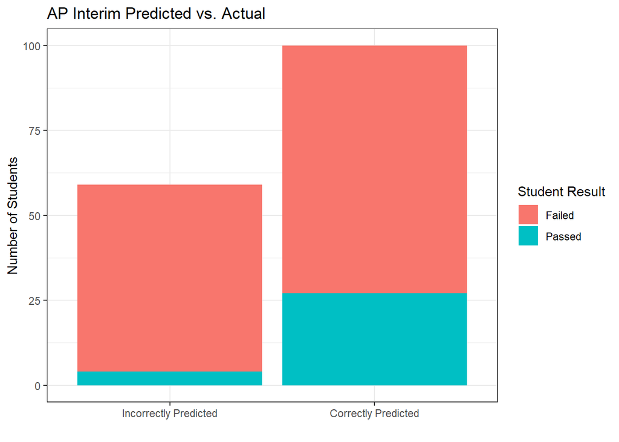

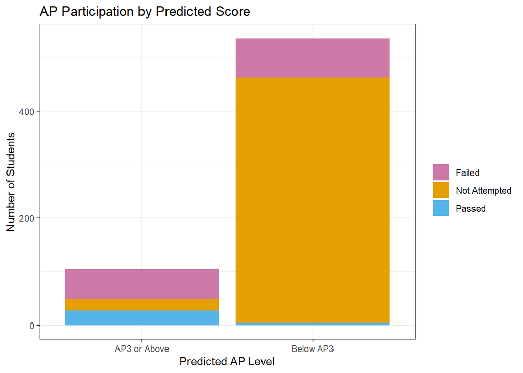

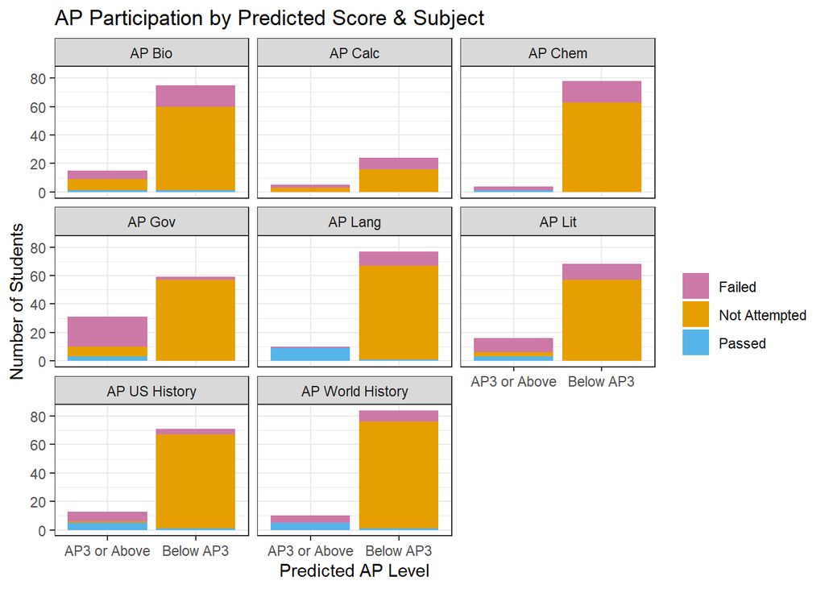

### Quantity of Tests Taken vs. Student Success

Another possible indicator of student success is the number of AP Test the student is attempting. There doesn’t appear to be any clear relationship between several tests taken and the number passed. The plot below indicates that students taking 3 tests were the most likely to pass at least one test. Contrarily, taking 2 AP tests had fewer pass at least one test than just taking a single test. The Pearson correlation (0.43) supports the conclusion of a small but unreliable relationship between tests taken and the number of tests the student passes. Further exploration of possible lurking variables should also be explored.

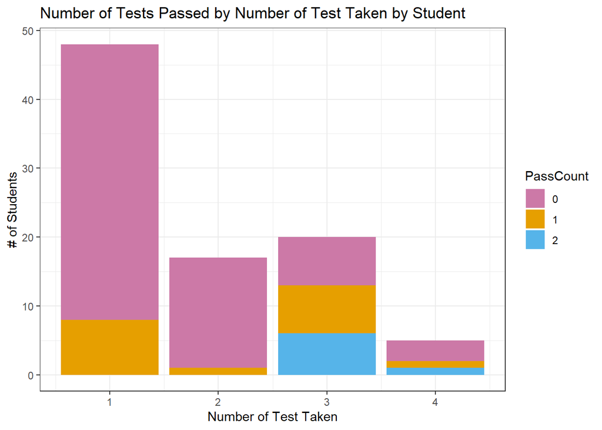

### Participation Rate

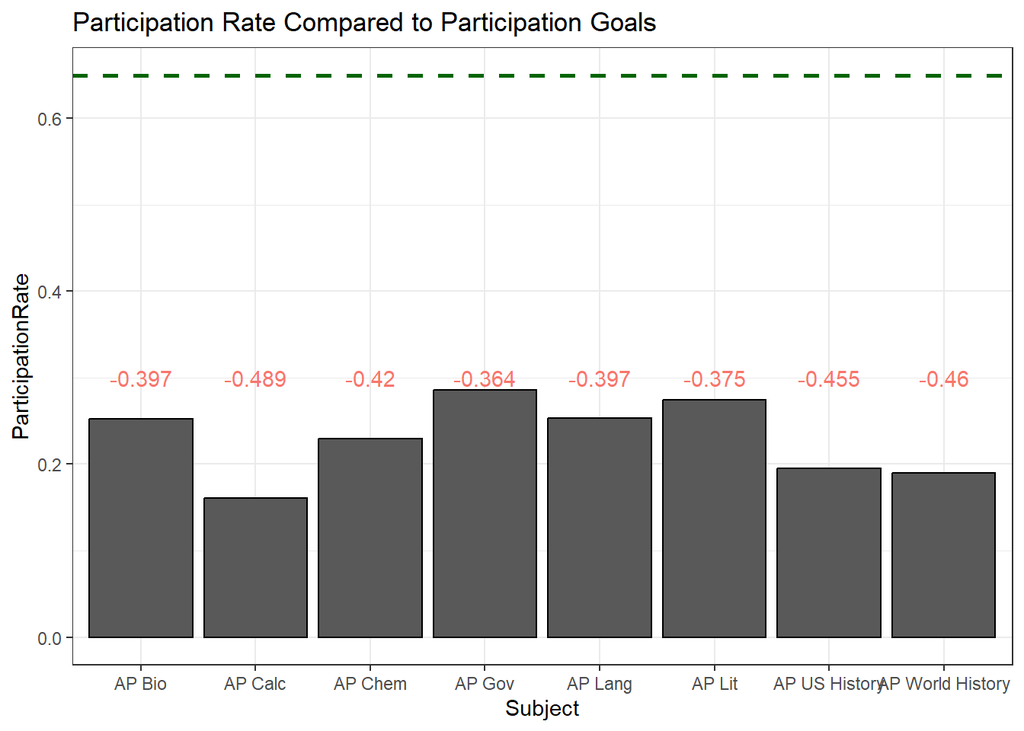

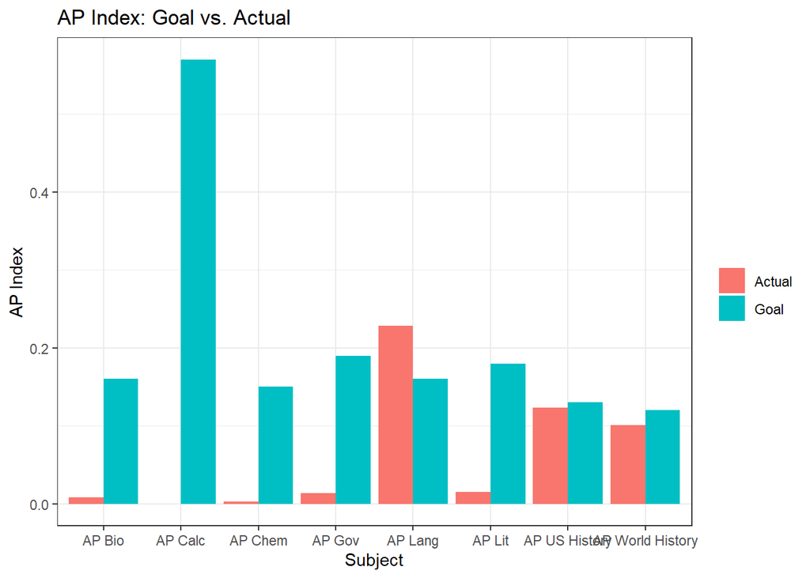